# A6_Tadepalli_Sai_Eshwar

Sai Eshwar Tadepalli

2023-07-12

## 1 - Load packages, prepare and inspect the data

1.A Package loading, and Walmart_visits_7trips.csv Download Walmart_visits_7trips.csv import and transformation. Show the overall structure of the input file. Transform factor variables, and show a summary of the input data file.

```r
# Installing packages from library
library(C50)
library(psych)
library(RWeka)
library(caret)
library(rminer)
library(matrixStats)
library(knitr)
library(arules)

cloud_wd <- getwd()
setwd(cloud_wd)

# Read csv files and set stringsAsFactors to False
walmart_visits <- read.csv(file = "Walmart_visits_7trips.csv", stringsAsFactors = FALSE)

str(walmart_visits)
```

```
## 'data.frame':    12734 obs. of  9 variables:
##  $ TripType    : int  999 999 999 999 999 999 999 999 999 999 ...
##  $ DOW         : chr  "Friday" "Friday" "Friday" "Friday" ...
##  $ UniqueItems : int  1 2 1 1 2 1 1 1 1 1 ...
##  $ TotalQty    : int  0 1 0 0 3 0 0 0 1 0 ...
##  $ RtrnQty     : int  1 1 1 1 0 1 1 1 0 1 ...
##  $ NetQty      : int  -1 0 -1 -1 3 -1 -1 -1 1 -1 ...
##  $ UniqDepts   : int  1 1 1 1 2 1 1 1 1 1 ...
##  $ OneItemDepts: int  1 0 1 1 2 1 1 1 1 1 ...
##  $ RtrnDepts   : int  1 1 1 1 0 1 1 1 0 1 ...
```

```r
# Factoring variable
walmart_visits$DOW = factor(walmart_visits$DOW)
walmart_visits$TripType = factor(walmart_visits$TripType)
str(walmart_visits)
```

```
## 'data.frame':    12734 obs. of  9 variables:
##  $ TripType    : Factor w/ 7 levels "5","7","8","9",..: 7 7 7 7 7 7 7 7 7 7 ...
##  $ DOW         : Factor w/ 7 levels "Friday","Monday",..: 1 1 1 1 1 1 1 1 1 1 ...
##  $ UniqueItems : int  1 2 1 1 2 1 1 1 1 1 ...
##  $ TotalQty    : int  0 1 0 0 3 0 0 0 1 0 ...
##  $ RtrnQty     : int  1 1 1 1 0 1 1 1 0 1 ...
##  $ NetQty      : int  -1 0 -1 -1 3 -1 -1 -1 1 -1 ...
##  $ UniqDepts   : int  1 1 1 1 2 1 1 1 1 1 ...
##  $ OneItemDepts: int  1 0 1 1 2 1 1 1 1 1 ...
##  $ RtrnDepts   : int  1 1 1 1 0 1 1 1 0 1 ...
```

```r
summary(walmart_visits)
```

```
##  TripType          DOW        UniqueItems         TotalQty          RtrnQty            NetQty
##  5  :1106   Friday   :1851   Min.   :  1.000   Min.   :  0.000   Min.   : 0.0000   Min.   :-52.000
##  7  :1305   Monday   :1765   1st Qu.:  1.000   1st Qu.:  1.000   1st Qu.: 0.0000   1st Qu.:  1.000
##  8  :2808   Saturday :1923   Median :  2.000   Median :  3.000   Median : 0.0000   Median :  2.000
##  9  :2046   Sunday   :2014   Mean   :  6.203   Mean   :  7.185   Mean   : 0.2431   Mean   :  6.942
##  39 :2229   Thursday :1738   3rd Qu.:  7.000   3rd Qu.:  8.000   3rd Qu.: 0.0000   3rd Qu.:  8.000
##  40 :1373   Tuesday  :1703   Max.   :113.000   Max.   :137.000   Max.   :52.0000   Max.   :137.000
##  999:1867   Wednesday:1740
##    UniqDepts       OneItemDepts      RtrnDepts
##  Min.   : 1.000   Min.   : 0.000   Min.   : 0.0000
##  1st Qu.: 1.000   1st Qu.: 1.000   1st Qu.: 0.0000
##  Median : 2.000   Median : 1.000   Median : 0.0000
##  Mean   : 3.194   Mean   : 1.918   Mean   : 0.1756
##  3rd Qu.: 4.000   3rd Qu.: 3.000   3rd Qu.: 0.0000
##  Max.   :21.000   Max.   :12.000   Max.   :10.0000
##
```

1.B Understand this data set using correlation analysis (pairs.panels from psych)

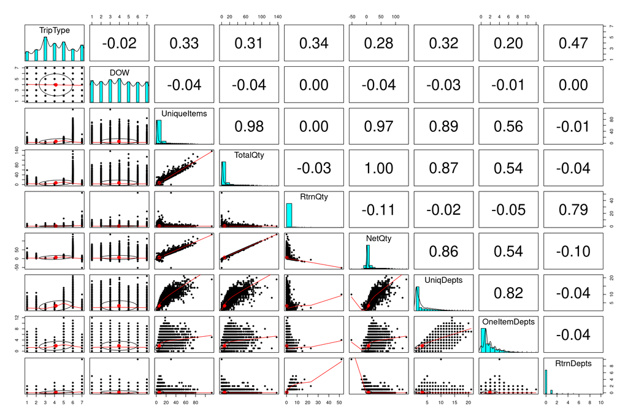

```r
pairs.panels(walmart_visits)
```

1.C Build a descriptive C5.0 decision tree using the entire data set (TripType is the target variable). Prune the tree so that the number of tree leaves is smaller than 15 (use CF value to prune the tree). Plot the tree and show summary of the model to view tree rules and confusion matrix.

```r
visits_m1_c50 <- C5.0(TripType~., walmart_visits, control = C5.0Control(CF = 0.035))
visits_m1_c50
```

```
##
## Call:
## C5.0.formula(formula = TripType ~ ., data = walmart_visits, control = C5.0Control(CF = 0.035))
##
## Classification Tree
## Number of samples: 12734
## Number of predictors: 8
##
## Tree size: 5
##
## Non-standard options: attempt to group attributes, confidence level: 0.035
```

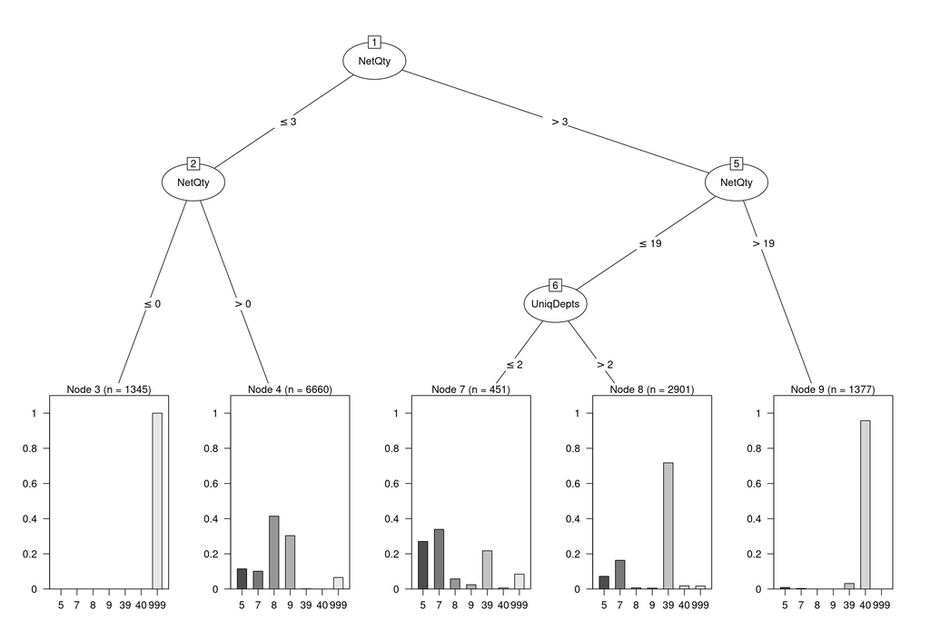

```r
plot(visits_m1_c50)
```

```r
summary(visits_m1_c50)
```

```
##
## Call:
## C5.0.formula(formula = TripType ~ ., data = walmart_visits, control = C5.0Control(CF = 0.035))
##
##
## C5.0 [Release 2.07 GPL Edition]      Thu Jul 13 03:44:58 2023
## -------------------------------
##
## Class specified by attribute `outcome'
##
## Read 12734 cases (9 attributes) from undefined.data
##
## Decision tree:
##
## NetQty <= 3:
## :...NetQty <= 0: 999 (1345)
## :   NetQty > 0: 8 (6660/3899)
## NetQty > 3:
## :...NetQty > 19: 40 (1377/59)
##     NetQty <= 19:
##     :...UniqDepts <= 2: 7 (451/298)
##         UniqDepts > 2: 39 (2901/820)
##
##
## Evaluation on training data (12734 cases):
##
##      Decision Tree
##    ----------------
##    Size      Errors
##
##       5 5076(39.9%)   <<
##
##
##     (a)   (b)   (c)   (d)   (e)   (f)   (g)    <-classified as
##    ----  ----  ----  ----  ----  ----  ----
##           122   763         209    12          (a): class 5
##           153   674         474     4          (b): class 7
##            26  2761          21                (c): class 8
##            11  2020          15                (d): class 9
##            98     7        2081    43          (e): class 39
##             3                52  1318          (f): class 40
##            38   435          49        1345    (g): class 999
##
##
##  Attribute usage:
##
##  100.00% NetQty
##   26.32% UniqDepts
##
##
## Time: 0.0 secs
```

> After factorizing TripType as the target variable for classification tree of C5.0 model with CF (confidence level) value equals 0.035, the tree size obtained is 5.

## 2 - Use SimpleKMeans clustering to understand visits

2.A Save the number of unique TripType in the imported data as TripType.levels. Remove TripType from input data.

```r
TripType.levels <- length(unique(walmart_visits$TripType))
walmart_visits_new <- walmart_visits[,-c(1)]
```

2.B Generate clusters with the default (i.e. random) initial cluster assignment and the default distance function (Euclidean). The number of clusters equals to TripType.levels. Show the clustering information with the standard deviations and the centroids of the clusters.

```r
nClusters <- TripType.levels

# SimpleKmeans with random initial cluster assignment and default Euclidean distance
walmarts_clustering <- SimpleKMeans(walmart_visits[,-1], Weka_control(N = nClusters, init = 0, A = "weka.core.EuclideanDistance", V = TRUE))
walmarts_clustering
```

```
##
## kMeans
## ======
##
## Number of iterations: 14
## Within cluster sum of squared errors: 3983.3256867784276
##
## Initial starting points (random):
##
## Cluster 0: Friday,4,0,4,-4,2,1,2
## Cluster 1: Wednesday,2,2,0,2,2,2,0
## Cluster 2: Thursday,1,0,1,-1,1,1,1
## Cluster 3: Wednesday,1,1,0,1,1,1,0
## Cluster 4: Sunday,1,1,1,0,1,1,1
## Cluster 5: Saturday,5,5,0,5,3,2,0
## Cluster 6: Friday,4,4,0,4,4,4,0
##
## Missing values globally replaced with mean/mode
##
## Final cluster centroids:
##                               Cluster#
## Attribute        Full Data           0           1           2           3           4           5           6
##                  (12734.0)    (1926.0)     (795.0)    (2359.0)    (2838.0)    (2319.0)    (1982.0)     (515.0)
## ==============================================================================================================
## DOW                 Sunday      Friday   Wednesday    Thursday   Wednesday      Sunday    Saturday      Friday
##   Friday       1851.0 ( 14%)1569.0 ( 81%)  0.0 (  0%)  0.0 (  0%)  0.0 (  0%)  0.0 (  0%)  0.0 (  0%)282.0 ( 54%)
##   Monday       1765.0 ( 13%)187.0 (  9%)216.0 ( 27%)320.0 ( 13%)707.0 ( 24%)158.0 (  6%) 35.0 (  1%)142.0 ( 27%)
##   Saturday     1923.0 ( 15%)  0.0 (  0%)  0.0 (  0%)  0.0 (  0%)  0.0 (  0%)  0.0 (  0%)1922.0 ( 96%)  1.0 (  0%)
##   Sunday       2014.0 ( 15%)  0.0 (  0%)  0.0 (  0%)  0.0 (  0%)  0.0 (  0%)2014.0 ( 86%)  0.0 (  0%)  0.0 (  0%)
##   Thursday     1738.0 ( 13%)  0.0 (  0%)  0.0 (  0%)1737.0 ( 73%)  0.0 (  0%)  0.0 (  0%)  0.0 (  0%)  1.0 (  0%)
##   Tuesday      1703.0 ( 13%)170.0 (  8%)210.0 ( 26%)302.0 ( 12%)760.0 ( 26%)147.0 (  6%) 25.0 (  1%) 89.0 ( 17%)
##   Wednesday    1740.0 ( 13%)  0.0 (  0%)369.0 ( 46%)  0.0 (  0%)1371.0 ( 48%)  0.0 (  0%)  0.0 (  0%)  0.0 (  0%)
##
## UniqueItems         6.2033      2.6651     14.1799      4.7512      2.0247      7.9461      6.7735     26.7592
##                  +/-9.1936   +/-2.8401   +/-8.4465   +/-7.3608   +/-1.6575  +/-10.1846    +/-9.323  +/-14.0425
##
## TotalQty            7.1849      2.8411     16.7157      5.5019      2.1945      9.2902      7.8158     32.0175
##                 +/-11.2831     +/-3.91  +/-10.7118   +/-9.3125   +/-2.2108   +/-12.458  +/-11.3376  +/-17.2611
##
## RtrnQty             0.2431      0.4361      0.2113       0.178      0.1853       0.229      0.2619      0.1786
##                  +/-0.9149   +/-0.9064   +/-1.9588   +/-0.5966   +/-0.8215    +/-0.808   +/-0.8843   +/-0.4783
##
## NetQty              6.9417       2.405     16.5044      5.3239      2.0092      9.0612       7.554     31.8388
##                 +/-11.3513   +/-4.1859  +/-10.9241   +/-9.3264   +/-2.3983  +/-12.5132  +/-11.4112  +/-17.1912
##
## UniqDepts           3.1938       1.812      7.2327      2.7897      1.4137      3.8482      3.4026     10.0369
##                  +/-3.0952   +/-1.2409   +/-2.0374   +/-2.4401   +/-0.7464   +/-3.2775   +/-3.1987   +/-2.6882
##
## OneItemDepts        1.9179      1.3032      4.2264      1.9262      0.9683      2.1458      1.9581       4.666
##                  +/-1.6439   +/-0.9011   +/-1.4281   +/-1.3618   +/-0.6762    +/-1.669   +/-1.6589   +/-2.0273
##
## RtrnDepts           0.1756      0.3344       0.122      0.1412      0.1163      0.1686      0.1821      0.1553
##                  +/-0.4553   +/-0.5473   +/-0.5254   +/-0.4035    +/-0.358   +/-0.4686    +/-0.473   +/-0.3935
```

> When analyzing with default random initial cluster assignment with SimpleKmeans model, we get an within cluster sum of squared error as 3983.32 and number of iterations as 14.

2.C Keep the number of clusters at TripType.levels and the Euclidean distance function. Change the initial cluster assignment method to the Kmeans++ method. Cluster the visits again and show the standard deviations and the centroids of the clusters.

```r
# SimpleKmeans++ without random initial cluster assignment and default Euclidean distance
walmarts_clustering_1 <- SimpleKMeans(walmart_visits[,-1], Weka_control(N = nClusters, init = 1, A = "weka.core.EuclideanDistance", V = TRUE))
walmarts_clustering_1
```

```
##
## kMeans
## ======
##
## Number of iterations: 22
## Within cluster sum of squared errors: 4012.5108332500567
##
## Initial starting points (k-means++):
##
## Cluster 0: Friday,4,0,4,-4,2,1,2
## Cluster 1: Wednesday,3,3,0,3,3,3,0
## Cluster 2: Tuesday,1,1,0,1,1,1,0
## Cluster 3: Sunday,3,4,0,4,3,3,0
## Cluster 4: Sunday,1,1,0,1,1,1,0
## Cluster 5: Saturday,3,3,0,3,3,3,0
## Cluster 6: Sunday,7,7,0,7,5,3,0
##
## Missing values globally replaced with mean/mode
##
## Final cluster centroids:
##                               Cluster#
## Attribute        Full Data           0           1           2           3           4           5           6
##                  (12734.0)    (1919.0)    (2418.0)    (1713.0)     (985.0)    (3117.0)    (2226.0)     (356.0)
## ==============================================================================================================
## DOW                 Sunday      Friday   Wednesday     Tuesday      Sunday      Sunday    Saturday      Sunday
##   Friday       1851.0 ( 14%)1851.0 ( 96%)  0.0 (  0%)  0.0 (  0%)  0.0 (  0%)  0.0 (  0%)  0.0 (  0%)  0.0 (  0%)
##   Monday       1765.0 ( 13%) 34.0 (  1%)332.0 ( 13%)  5.0 (  0%)273.0 ( 27%)863.0 ( 27%)153.0 (  6%)105.0 ( 29%)
##   Saturday     1923.0 ( 15%)  0.0 (  0%)  0.0 (  0%)  0.0 (  0%)  0.0 (  0%)  0.0 (  0%)1918.0 ( 86%)  5.0 (  1%)
##   Sunday       2014.0 ( 15%)  0.0 (  0%)  0.0 (  0%)  0.0 (  0%)496.0 ( 50%)1353.0 ( 43%)  0.0 (  0%)165.0 ( 46%)
##   Thursday     1738.0 ( 13%) 34.0 (  1%)348.0 ( 14%)  6.0 (  0%)216.0 ( 21%)901.0 ( 28%)155.0 (  6%) 78.0 ( 21%)
##   Tuesday      1703.0 ( 13%)  0.0 (  0%)  0.0 (  0%)1702.0 ( 99%)  0.0 (  0%)  0.0 (  0%)  0.0 (  0%)  1.0 (  0%)
##   Wednesday    1740.0 ( 13%)  0.0 (  0%)1738.0 ( 71%)  0.0 (  0%)  0.0 (  0%)  0.0 (  0%)  0.0 (  0%)  2.0 (  0%)
##
## UniqueItems         6.2033      5.8223      4.4438      5.4513     13.3157      1.9695       6.894     36.8989
##                  +/-9.1936   +/-8.4507   +/-6.4714   +/-8.0628   +/-5.9249   +/-1.7448   +/-8.5702  +/-13.8774
##
## TotalQty            7.1849      6.8312      5.0211      6.2633     15.6132      2.0873      8.0139     44.3511
##                 +/-11.2831  +/-10.4718   +/-7.8996   +/-9.8533   +/-7.4901    +/-2.391  +/-10.5152  +/-18.1799
##
## RtrnQty             0.2431      0.2163      0.2151       0.258      0.1594      0.2913      0.2439      0.3118
##                  +/-0.9149   +/-0.7028   +/-0.8177   +/-1.4701   +/-0.6502    +/-0.829   +/-0.8534   +/-0.7438
##
## NetQty              6.9417      6.6149       4.806      6.0053     15.4538       1.796        7.77     44.0393
##                 +/-11.3513  +/-10.5405   +/-7.9509  +/-10.0445   +/-7.5348   +/-2.6281  +/-10.6032   +/-18.109
##
## UniqDepts           3.1938      3.0177      2.7506      2.9475      6.9066       1.368      3.5234     11.9916
##                  +/-3.0952   +/-2.9219   +/-2.3871   +/-2.7893   +/-1.6359   +/-0.6973     +/-2.99   +/-2.4165
##
## OneItemDepts        1.9179      1.8015      1.9467      1.8389      3.9259      0.9599      2.0184      4.9326
##                  +/-1.6439   +/-1.6116   +/-1.3431   +/-1.6053   +/-1.4704   +/-0.6262   +/-1.5893   +/-2.0952
##
## RtrnDepts           0.1756      0.1584      0.1667      0.1646      0.1259      0.2092      0.1716        0.25
##                  +/-0.4553   +/-0.4222   +/-0.4557   +/-0.4746   +/-0.4376   +/-0.4524   +/-0.4656   +/-0.5111
```

> When analyzing cluster assignment with Kmeans++ model, we get an within cluster sum of squared error as 4012.51 and number of iterations as 22.

2.D Keep the number of clusters at TripType.levels and the initial cluster assignment method to be the Kmeans++ method. Change the distance function to “weka.core.ManhattanDistance”. Cluster the visits again and show the standard deviations and the centroids of the clusters.

```r
# SimpleKmeans++ with random initial cluster assignment and Manhattan distance
walmarts_clustering_2 <- SimpleKMeans(walmart_visits[,-1], Weka_control(N = nClusters, init = 1, A = "weka.core.ManhattanDistance", V = TRUE))
walmarts_clustering_2
```

```
##
## kMeans
## ======
##
## Number of iterations: 15
## Sum of within cluster distances: 6719.908977218368
##
## Initial starting points (k-means++):
##
## Cluster 0: Friday,4,0,4,-4,2,1,2
## Cluster 1: Wednesday,2,3,0,3,2,2,0
## Cluster 2: Monday,2,2,0,2,2,2,0
## Cluster 3: Sunday,1,1,0,1,1,1,0
## Cluster 4: Friday,2,2,0,2,1,0,0
## Cluster 5: Thursday,25,26,0,26,9,3,0
## Cluster 6: Sunday,9,10,0,10,7,6,0
##
## Missing values globally replaced with mean/mode
##
## Final cluster centroids:
##                               Cluster#
## Attribute        Full Data           0           1           2           3           4           5           6
##                  (12734.0)    (1169.0)    (2049.0)    (2125.0)    (2561.0)    (1715.0)    (2045.0)    (1070.0)
## ==============================================================================================================
## DOW                 Sunday      Friday   Wednesday      Monday      Sunday      Friday    Thursday      Sunday
##   Friday       1851.0 ( 14%)579.0 ( 49%)  0.0 (  0%)  0.0 (  0%)  0.0 (  0%)1272.0 ( 74%)  0.0 (  0%)  0.0 (  0%)
##   Monday       1765.0 ( 13%)  0.0 (  0%)  0.0 (  0%)1765.0 ( 83%)  0.0 (  0%)  0.0 (  0%)  0.0 (  0%)  0.0 (  0%)
##   Saturday     1923.0 ( 15%)315.0 ( 26%)150.0 (  7%)193.0 (  9%)566.0 ( 22%)220.0 ( 12%)195.0 (  9%)284.0 ( 26%)
##   Sunday       2014.0 ( 15%)  0.0 (  0%)  0.0 (  0%)  0.0 (  0%)1448.0 ( 56%)  0.0 (  0%)  0.0 (  0%)566.0 ( 52%)
##   Thursday     1738.0 ( 13%)  0.0 (  0%)  0.0 (  0%)  0.0 (  0%)  0.0 (  0%)  0.0 (  0%)1687.0 ( 82%) 51.0 (  4%)
##   Tuesday      1703.0 ( 13%)275.0 ( 23%)159.0 (  7%)167.0 (  7%)547.0 ( 21%)223.0 ( 13%)163.0 (  7%)169.0 ( 15%)
##   Wednesday    1740.0 ( 13%)  0.0 (  0%)1740.0 ( 84%)  0.0 (  0%)  0.0 (  0%)  0.0 (  0%)  0.0 (  0%)  0.0 (  0%)
##
## UniqueItems              2          10           2           2           1           2           3          20
##                  +/-9.1936   +/-8.8363   +/-7.2403   +/-9.0595   +/-1.9094   +/-1.2026   +/-6.1102  +/-12.9739
##
## TotalQty                 3          11           3           2           1           2           3          24
##                 +/-11.2831  +/-11.2063   +/-8.8913  +/-11.0409   +/-2.5072   +/-1.9376   +/-7.9809  +/-16.0402
##
## RtrnQty                  0           0           0           0           0           0           0           0
##                  +/-0.9149   +/-0.5421   +/-0.8702   +/-0.8071   +/-0.8856   +/-0.7224   +/-0.8244   +/-1.6892
##
## NetQty                   2          11           3           2           1           2           3          24
##                 +/-11.3513  +/-11.2001   +/-8.9299  +/-11.1051   +/-2.7911   +/-2.1764   +/-8.0788  +/-16.1197
##
## UniqDepts                2           5           2           2           1           1           2           9
##                  +/-3.0952   +/-2.3526   +/-2.6134   +/-2.9729   +/-0.9383   +/-0.5359   +/-2.1538   +/-2.7216
##
## OneItemDepts             1           3           2           2           1           1           1           4
##                  +/-1.6439   +/-1.6097   +/-1.4613   +/-1.5243   +/-0.7255   +/-0.6736   +/-1.3203    +/-1.837
##
## RtrnDepts                0           0           0           0           0           0           0           0
##                  +/-0.4553   +/-0.3825   +/-0.4383   +/-0.4804   +/-0.4832   +/-0.4011   +/-0.4523    +/-0.506
```

2.E Choose your own distance function and initial cluster assignment method, increase or decrease the number of clusters. Cluster the visits again and show the standard deviations and the centroids of the clusters.

```r
# SimpleKmeans++ with random initial cluster assignment and Manhattan distance
walmarts_clustering_3 <- SimpleKMeans(walmart_visits[,-1], Weka_control(N = 3, init = 1, A = "weka.core.ManhattanDistance", V = TRUE))
walmarts_clustering_3
```

```
##
## kMeans
## ======
##
## Number of iterations: 4
## Sum of within cluster distances: 11181.260176384074
##
## Initial starting points (k-means++):
##
## Cluster 0: Friday,4,0,4,-4,2,1,2
## Cluster 1: Wednesday,2,3,0,3,2,2,0
## Cluster 2: Monday,2,2,0,2,2,2,0
##
## Missing values globally replaced with mean/mode
##
## Final cluster centroids:
##                               Cluster#
## Attribute        Full Data           0           1           2
##                  (12734.0)    (3058.0)    (5477.0)    (4199.0)
## ==============================================================
## DOW                 Sunday      Friday   Wednesday      Monday
##   Friday       1851.0 ( 14%)1851.0 ( 60%)  0.0 (  0%)  0.0 (  0%)
##   Monday       1765.0 ( 13%)  0.0 (  0%)  0.0 (  0%)1765.0 ( 42%)
##   Saturday     1923.0 ( 15%)298.0 (  9%)987.0 ( 18%)638.0 ( 15%)
##   Sunday       2014.0 ( 15%)317.0 ( 10%)1098.0 ( 20%)599.0 ( 14%)
##   Thursday     1738.0 ( 13%)292.0 (  9%)846.0 ( 15%)600.0 ( 14%)
##   Tuesday      1703.0 ( 13%)300.0 (  9%)806.0 ( 14%)597.0 ( 14%)
##   Wednesday    1740.0 ( 13%)  0.0 (  0%)1740.0 ( 31%)  0.0 (  0%)
##
## UniqueItems              2           2           5           1
##                  +/-9.1936   +/-6.8908  +/-10.8021     +/-6.89
##
## TotalQty                 3           3           6           1
##                 +/-11.2831   +/-8.5752  +/-13.2874    +/-8.394
##
## RtrnQty                  0           0           0           0
##                  +/-0.9149   +/-0.6416   +/-1.0661   +/-0.8607
##
## NetQty                   2           3           6           1
##                 +/-11.3513   +/-8.6121  +/-13.3353   +/-8.4992
##
## UniqDepts                2           1           3           1
##                  +/-3.0952    +/-2.461   +/-3.3386    +/-2.374
##
## OneItemDepts             1           1           2           1
##                  +/-1.6439   +/-1.4767    +/-1.705   +/-1.2021
##
## RtrnDepts                0           0           0           0
##                  +/-0.4553   +/-0.3632   +/-0.4817   +/-0.4707
```

## 3 - Market Basket Analysis with the Walmart dept baskets

3.A Import Walmart_baskets_1week.csv Download Walmart_baskets_1week.csv using the following read.transactions() with the “single” format (for long format) and save it in a sparse matrix called, e.g., Dept_baskets.

```r
Dept_baskets <- read.transactions("Walmart_baskets_1week.csv", format="single", sep = ",", header = TRUE, cols=c("VisitNumber","DepartmentDescription"))

summary(Dept_baskets)
```

```
## transactions as itemMatrix in sparse format with
##  2000 rows (elements/itemsets/transactions) and
##  66 columns (items) and a density of 0.0507803
##
## most frequent items:
##         DSD GROCERY   GROCERY DRY GOODS IMPULSE MERCHANDISE             PRODUCE               DAIRY
##                 612                 433                 414                 386                 384
##             (Other)
##                4474
##
## element (itemset/transaction) length distribution:
## sizes
##   1   2   3   4   5   6   7   8   9  10  11  12  13  14  15  16  17
## 693 372 246 173 127 112  70  67  49  34  20   9  12   9   2   3   2
##
##    Min. 1st Qu.  Median    Mean 3rd Qu.    Max.
##   1.000   1.000   2.000   3.352   5.000  17.000
##
## includes extended item information - examples:
##        labels
## 1  1-HR PHOTO
## 2 ACCESSORIES
## 3  AUTOMOTIVE
##
## includes extended transaction information - examples:
##   transactionID
## 1         10009
## 2         10034
## 3         10051
```

3.B Inspect the first 15 transactions.

```r
# look at the first fifteen transactions
inspect(Dept_baskets[1:15])
```

```
##      items                         transactionID
## [1]  {IMPULSE MERCHANDISE}                 10009
## [2]  {CANDY, TOBACCO, COOKIES,
##       HOME MANAGEMENT,
##       JEWELRY AND SUNGLASSES,
##       MENS WEAR}                           10034
## [3]  {GIRLS WEAR, 4-6X  AND 7-14,
##       GROCERY DRY GOODS,
##       IMPULSE MERCHANDISE,
##       PERSONAL CARE}                       10051
## [4]  {OTHER DEPARTMENTS}                   10118
## [5]  {FINANCIAL SERVICES}                  10167
## [6]  {DAIRY,
##       DSD GROCERY,
##       FROZEN FOODS,
##       GROCERY DRY GOODS,
##       MEAT - FRESH & FROZEN,
##       PERSONAL CARE,
##       PRE PACKED DELI,
##       SLEEPWEAR/FOUNDATIONS}               10178
## [7]  {PHARMACY OTC}                        10191
## [8]  {FINANCIAL SERVICES}                  10206
## [9]  {INFANT CONSUMABLE HARDLINES}         1022
## [10] {CELEBRATION,
##       FABRICS AND CRAFTS,
##       OFFICE SUPPLIES,
##       TOYS}                                10250
## [11] {PHARMACY OTC}                        10272
## [12] {FABRICS AND CRAFTS,
##       GROCERY DRY GOODS,
##       PRODUCE}                             10273
## [13] {SERVICE DELI}                        1029
## [14] {BEAUTY,
##       DSD GROCERY,
##       GROCERY DRY GOODS,
##       HOME DECOR,
##       HOME MANAGEMENT,
##       HOUSEHOLD CHEMICALS/SUPP,
##       HOUSEHOLD PAPER GOODS,
##       LAWN AND GARDEN,
##       PAINT AND ACCESSORIES,
##       PERSONAL CARE,
##       PETS AND SUPPLIES}                   10296
## [15] {BEAUTY}                              10302
```

3.C Use the itemFrequencyPlot command to plot the most frequent 15 items in the descending order of transaction frequency in percentage.

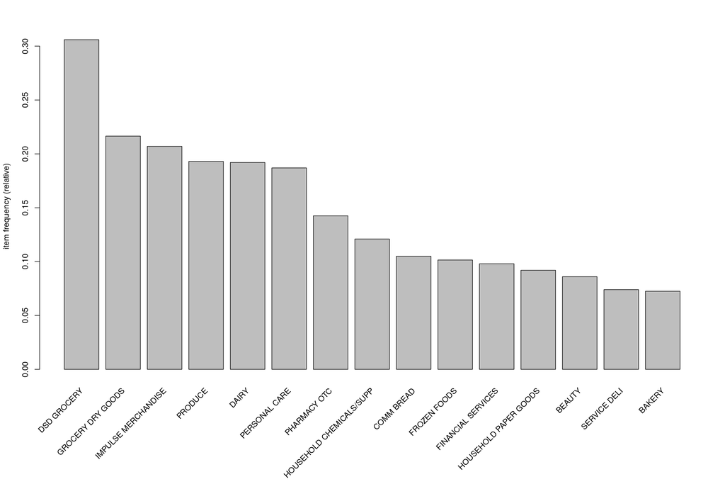

```r
# top 15 most frequent words
itemFrequencyPlot(Dept_baskets, type="relative", topN = 15)
```

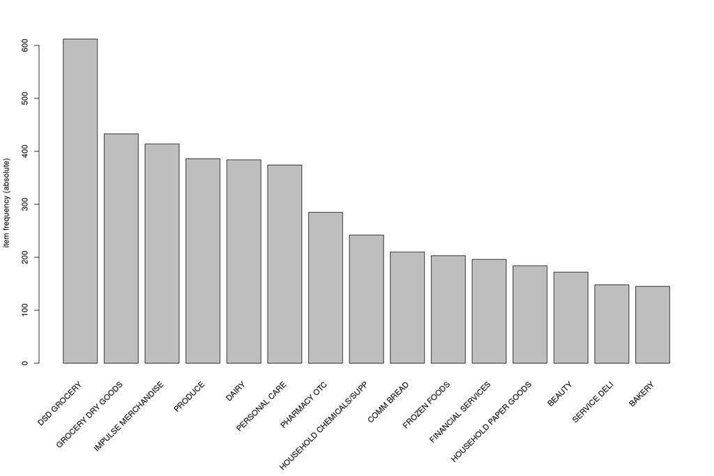

```r
itemFrequencyPlot(Dept_baskets, type="absolute", topN = 15)
```

3.D Associate rule mining

1. Use the apriori command to generate about 50 to 100 association rules from the input data. Set your own minimum support and confidence threshold levels. Remember if the thresholds are too low, you will generate more rules than desired, or if you set them too high, you may not generate any or a sufficient number of rules. Show the rules in the descending order of their lift values.

```r
Depts_baskets_c1 <- apriori(Dept_baskets, parameter = list(support = 0.05, confidence = 0.25))
```

```
## Apriori
##
## Parameter specification:
##  confidence minval smax arem  aval originalSupport maxtime support minlen maxlen target  ext
##        0.25    0.1    1 none FALSE            TRUE       5    0.05      1     10  rules TRUE
##
## Algorithmic control:
##  filter tree heap memopt load sort verbose
##     0.1 TRUE TRUE  FALSE TRUE    2    TRUE
##
## Absolute minimum support count: 100
##
## set item appearances ...[0 item(s)] done [0.00s].
## set transactions ...[66 item(s), 2000 transaction(s)] done [0.00s].
## sorting and recoding items ... [20 item(s)] done [0.00s].
## creating transaction tree ... done [0.00s].
## checking subsets of size 1 2 3 4 done [0.00s].
## writing ... [79 rule(s)] done [0.00s].
## creating S4 object  ... done [0.00s].
```

```r
inspect(sort(Depts_baskets_c1, by = "lift"))
```

```
##      lhs                                          rhs                     support confidence
## [1]  {DAIRY, GROCERY DRY GOODS}                => {COMM BREAD}            0.0560  0.4786325
## [2]  {DSD GROCERY, GROCERY DRY GOODS}          => {COMM BREAD}            0.0590  0.4521073
## [3]  {DSD GROCERY, GROCERY DRY GOODS, PRODUCE} => {DAIRY}                 0.0590  0.8137931
## [4]  {DAIRY, GROCERY DRY GOODS}                => {FROZEN FOODS}          0.0500  0.4273504
## [5]  {DSD GROCERY, GROCERY DRY GOODS}          => {FROZEN FOODS}          0.0545  0.4176245
## [6]  {FROZEN FOODS, GROCERY DRY GOODS}         => {DAIRY}                 0.0500  0.7874016
## [7]  {DAIRY, DSD GROCERY}                      => {FROZEN FOODS}          0.0505  0.4122449
## [8]  {DAIRY, DSD GROCERY}                      => {COMM BREAD}            0.0520  0.4244898
## [9]  {COMM BREAD, DAIRY}                       => {GROCERY DRY GOODS}     0.0560  0.8615385
## [10] {DAIRY, DSD GROCERY, PRODUCE}             => {GROCERY DRY GOODS}     0.0590  0.8368794
## [11] {COMM BREAD, GROCERY DRY GOODS}           => {DAIRY}                 0.0560  0.7320261
## [12] {DAIRY, FROZEN FOODS}                     => {GROCERY DRY GOODS}     0.0500  0.8064516
## [13] {COMM BREAD, DSD GROCERY}                 => {GROCERY DRY GOODS}     0.0590  0.8027211
## [14] {COMM BREAD, DSD GROCERY}                 => {DAIRY}                 0.0520  0.7074830
```

[output cut: 145 more lines]

```r
Depts_baskets_c2 <- apriori(Dept_baskets, parameter = list(support = 0.05, confidence = 0.02))
```

```
## Apriori
##
## Parameter specification:
##  confidence minval smax arem  aval originalSupport maxtime support minlen maxlen target  ext
##        0.02    0.1    1 none FALSE            TRUE       5    0.05      1     10  rules TRUE
##
## Algorithmic control:
##  filter tree heap memopt load sort verbose
##     0.1 TRUE TRUE  FALSE TRUE    2    TRUE
##
## Absolute minimum support count: 100
##
## set item appearances ...[0 item(s)] done [0.00s].
## set transactions ...[66 item(s), 2000 transaction(s)] done [0.00s].
## sorting and recoding items ... [20 item(s)] done [0.00s].
## creating transaction tree ... done [0.00s].
## checking subsets of size 1 2 3 4 done [0.00s].
## writing ... [106 rule(s)] done [0.00s].
## creating S4 object  ... done [0.00s].
```

```r
inspect(sort(Depts_baskets_c2, by = "lift"))
```

```
##       lhs                                          rhs                           support confidence
## [1]   {DAIRY, GROCERY DRY GOODS}                => {COMM BREAD}                  0.0560  0.4786325
## [2]   {DSD GROCERY, GROCERY DRY GOODS}          => {COMM BREAD}                  0.0590  0.4521073
## [3]   {DSD GROCERY, GROCERY DRY GOODS, PRODUCE} => {DAIRY}                       0.0590  0.8137931
## [4]   {DAIRY, GROCERY DRY GOODS}                => {FROZEN FOODS}                0.0500  0.4273504
## [5]   {DSD GROCERY, GROCERY DRY GOODS}          => {FROZEN FOODS}                0.0545  0.4176245
## [6]   {FROZEN FOODS, GROCERY DRY GOODS}         => {DAIRY}                       0.0500  0.7874016
## [7]   {DAIRY, DSD GROCERY}                      => {FROZEN FOODS}                0.0505  0.4122449
## [8]   {DAIRY, DSD GROCERY}                      => {COMM BREAD}                  0.0520  0.4244898
## [9]   {COMM BREAD, DAIRY}                       => {GROCERY DRY GOODS}           0.0560  0.8615385
## [10]  {DAIRY, DSD GROCERY, PRODUCE}             => {GROCERY DRY GOODS}           0.0590  0.8368794
## [11]  {COMM BREAD, GROCERY DRY GOODS}           => {DAIRY}                       0.0560  0.7320261
## [12]  {DAIRY, FROZEN FOODS}                     => {GROCERY DRY GOODS}           0.0500  0.8064516
## [13]  {COMM BREAD, DSD GROCERY}                 => {GROCERY DRY GOODS}           0.0590  0.8027211
## [14]  {COMM BREAD, DSD GROCERY}                 => {DAIRY}                       0.0520  0.7074830
```

[output cut: 199 more lines]

> When applying apriori model to perform association rule mining with support as 0.05 and confidence threshold set to 0.02, we get coverage, lift and count of each rule associated with it. Among them, rule with LHS equal to {DAIRY, GROCERY DRY GOODS} and RHS {COMM BREAD} has high lift value of 4.55 and count equivalent to 112 and coverage 0.1170. Similarly, {} to {DSD GROCERY} has least lift value of 1 and count 612. In total, we got 106 association rules in this model.

## Task II Reflections

What have you learned from building each of these models and the modeling impact of your adjustments to the hyperparameters or dataset? What can you say about the clusters that were formed? Is there anything interesting to point out? Recall clustering is often used to discover latent (hidden) information. What have you discovered? Make sure to discuss the association rule mining results as well.

If you were explaining the results of these models to a supervisor what would you say about them? Attempt to do more than just state facts here, interpret the results. Coding is great, interpretation of output is even more important. Discuss each model. Write at least 150 words.

> Finally, we utilize the apriori model to perform association rule mining, with support set to 0.05 and confidence set to 0.02, to get coverage, lift, and count for each rule associated with it. Among them, the rule with LHS equal to {DAIRY, GROCERY DRY GOODS, and RHS} equal to {COMM BREAD} has a high lift value of 4.55, a count of 112, and coverage of 0.1170. Similarly, {} to {DSD GROCERY} has the lowest lift value of 1 and the highest count of 612. This model contains a total of 106 association rules. The association rule mining technique is used to extract associations between items, revealing the customer purchase behaviors. In a similar manner, while using an apriori model to execute association rule mining with a support level of 0.05 and a confidence threshold of 0.02, we obtain coverage, lift, and count for each rule related to it. Among them, the rule with LHS equal to {DAIRY, GROCERY DRY GOODS} and RHS equal to {COMM BREAD} has a high lift value of 4.55 and counts equal to 112 while having a coverage of 0.1170. Comparably, {} to {DSD GROCERY} has least lift value of 1 and count 612. In total, we got 106 association rules in this model.